# t-SNE Visualizatiion and GO Enrichment Analysis Human Brain snATAC-seq

Nils Schlatter

2025-06-11

## Libraries

```r
suppressPackageStartupMessages({
  library(rtracklayer); library(GenomicRanges); library(BiocFileCache)
  library(rGREAT);      library(ChIPseeker);   library(clusterProfiler)
  library(org.Hs.eg.db);library(TxDb.Hsapiens.UCSC.hg38.knownGene)
  library(BiocParallel);library(dplyr);        library(ggplot2)
  library(DT);          library(enrichplot);   library(cli)
  library(Rtsne);       library(ggrepel);      library(pheatmap)
  library(UpSetR);      library(tidyr);         library(tibble)
  library(cowplot);     library(patchwork)
})
```

## Configuration

```r
param <- MulticoreParam(workers = params$workers)
cache_dir <- path.expand("~/.cache/BiocFileCache")
if (!dir.exists(cache_dir)) dir.create(cache_dir, recursive = TRUE, mode = "0755")
bfc <- BiocFileCache(cache = cache_dir)

# Databases
txdb <- TxDb.Hsapiens.UCSC.hg38.knownGene
base_url <- "https://decoder-genetics.wustl.edu/catlasv1/catlas_downloads/humanbrain/bigwig/"

# Cell type groups
cell_type_groups <- list(
  Excitatory = c("ITL4_1","ITL4_2","ITL5_1","ITL5_2","ITL5_3","ITL5_4",
                 "ITL6_1_1","ITL6_1_2","ITL6_2_1","ITL6_2_2","ITL23_1","ITL23_2"),
  Inhibitory = c("PVALB_1","PVALB_2","PVALB_3","PVALB_4","PV_ChCs",
                 "SST_1","SST_2","SST_3","SST_4","SST_5","SST_CHODL",
                 "VIP_1","VIP_2","VIP_3","VIP_4","VIP_5","VIP_6","VIP_7",
                 "LAMP5_1","LAMP5_2","SNCG_1","SNCG_2","SNCG_3","SNCG_4","SNCG_5"),
  Glia = c("ASCT_1","ASCT_2","ASCT_3","ASCNT_1","ASCNT_2","ASCNT_3",
           "OGC_1","OGC_2","OGC_3","OPC","MGC_1","MGC_2"),
  Other = c("MSN_1","MSN_2","MSN_3","D1CaB","D2CaB","D1Pu","D2Pu")
)
all_cell_types <- unlist(cell_type_groups)

# Colors
group_colors <- c(Excitatory = "#E31A1C", Inhibitory = "#1F78B4",
                  Glia = "#33A02C", Other = "#FF7F00")

expand_ontology_name <- function(ont) {
  switch(ont, BP = "Biological Process", MF = "Molecular Function",
              CC = "Cellular Component", ont)
}

background_names <- c(
  accessible = "Accessible Background",
  genome = "Genome Background",
  self = "Self Background"
)

cli::cli_alert_info("Processing {length(all_cell_types)} cell types in {length(cell_type_groups)} groups")
```

## Background Comparison Explained

The analysis compares **three different background gene sets** for GO enrichment:

1. **`accessible`**  
   Genes accessible in *any* cell type  
   *Answers: “What makes this cell group unique compared to others?”*
2. **`genome`**  
   All annotated genes in the genome  
   *Answers: “What biological functions are overrepresented vs. the whole genome?”*
3. **`self`**  
   Only genes accessible in the *current group*  
   *Answers: “What functions are enriched within the group’s own accessible genes?”*

## Helper Functions

```r
# Download/parse bigWig regions
get_accessible_regions <- function(cell_type) {
  url <- paste0(base_url, cell_type, ".bw")
  bw <- tryCatch({
    options(timeout = 900)
    file <- bfcrpath(bfc, url)
    if (!file.exists(file) || file.size(file) == 0) return(GRanges())
    import(file, format = "BigWig")
  }, error = function(e) GRanges())
  options(timeout = 60)
  if (length(bw) == 0) return(GRanges())
  bw <- bw[!is.na(bw$score) & bw$score > params$threshold]
  if (length(bw) > params$top_n) bw <- head(bw[order(bw$score, decreasing = TRUE)], params$top_n)
  bw
}

# Combine group ranges
combine_group_ranges <- function(cts) {
  valid <- Filter(function(x) length(x) > 0, accessibility_regions[cts])
  if (length(valid) == 0) return(GRanges())
  comb <- reduce(Reduce(c, valid))
  if (length(comb) > params$max_regions) comb <- head(comb, params$max_regions)
  comb
}

# GO enrichment with selectable background
perform_go_enrichment <- function(ranges, group_name, background = c("accessible","genome","self")) {
  background <- match.arg(background)
  if (length(ranges) < 100) { cli::cli_alert_warning("{group_name}: too few regions ({length(ranges)})"); return(NULL) }
  ann <- tryCatch({ annotatePeak(ranges, TxDb = txdb, annoDb = "org.Hs.eg.db",
                                 tssRegion = c(-3000, 3000), verbose = FALSE) },
                  error = function(e) NULL)
  if (is.null(ann)) return(NULL)
  genes <- unique(na.omit(ann@anno$geneId))
  if (length(genes) < 10) return(NULL)
  cli::cli_alert_info("{group_name}: {length(genes)} genes")
  universe <- switch(background,
                     accessible = universe_genes_accessible,
                     genome      = all_genes,
                     self        = genes)
  go_list <- lapply(c("BP","MF","CC"), function(ont) {
    res <- tryCatch({enrichGO(gene = genes, OrgDb = org.Hs.eg.db, ont = ont,
                              universe = universe, pvalueCutoff = 0.05,
                              qvalueCutoff = 0.2, readable = TRUE)}, error=function(e) NULL)
    if (!is.null(res) && nrow(res@result) > 0) {
      res <- tryCatch(simplify(res, cutoff = 0.7), error=function(e) res)
    }
    res
  })
  names(go_list) <- c("BP","MF","CC")
  c(go_list, list(n_genes = length(genes), n_regions = length(ranges)))
}

# Extract enriched terms
extract_enriched_terms <- function(enrich_res, ontology = params$ontology, top_n = 10) {
  do.call(rbind, lapply(names(enrich_res), function(grp){
    res <- enrich_res[[grp]][[ontology]]
    if (!inherits(res, "enrichResult") || is.null(res)) return(NULL)
    df  <- as.data.frame(res)
    if (nrow(df) == 0) return(NULL)
    df$Group <- grp
    df[1:min(nrow(df), top_n), c("ID","Description","p.adjust","Group")]
  }))
}

# Create summary table
create_summary <- function(results) {
  summary_df <- data.frame()

  for (grp in names(results)) {
    res_grp <- results[[grp]]

    for (ont in c("BP","MF","CC")) {
      if (!is.null(res_grp) && !is.null(res_grp[[ont]]) && nrow(res_grp[[ont]]@result) > 0) {
        top_term <- res_grp[[ont]]@result[1, ]
        summary_df <- rbind(summary_df, data.frame(
          Group = grp,
          Ontology = expand_ontology_name(ont),
          Significant_Terms = nrow(res_grp[[ont]]@result),
          Top_Term = top_term$Description,
          Top_P_Value = top_term$p.adjust,
          Gene_Count = top_term$Count
        ))
      } else {
        summary_df <- rbind(summary_df, data.frame(
          Group = grp,
          Ontology = expand_ontology_name(ont),
          Significant_Terms = 0,
          Top_Term = ifelse(is.null(res_grp), "Analysis failed", "No significant terms"),
          Top_P_Value = NA_real_,
          Gene_Count = NA_integer_
        ))
      }
    }
  }
  return(summary_df)
}

# Generate ontology plots
generate_ontology_plots <- function(enrich_list, ont, bg_name) {
  plot_list <- list()
  for (grp in names(enrich_list)) {
    res <- enrich_list[[grp]]
    if (is.null(res) || is.null(res[[ont]])) next
    if (nrow(res[[ont]]@result) == 0) next

    plot_list[[grp]] <- dotplot(res[[ont]], showCategory = 10, font.size = 11) +
      ggtitle(grp) +
      theme_minimal() +
      scale_color_gradient(
        low = group_colors[[grp]],
        high = "darkred",
        name = "-log10(adj-p)",
        trans = "log10"
      ) +
      theme(
        plot.title = element_text(face = "bold", size = 12, hjust = 0.5),
        legend.position = "bottom",
        plot.margin = margin(5, 10, 5, 10)
      ) +
      guides(color = guide_colorbar(barwidth = 10, barheight = 0.8))
  }
  return(plot_list)
}
```

## Load & Process Accessibility Data

```r
cli::cli_h2("Loading accessibility data")
accessibility_regions <- bplapply(all_cell_types, get_accessible_regions, BPPARAM = param)
names(accessibility_regions) <- all_cell_types

# Combine to group level
group_accessibility <- lapply(cell_type_groups, combine_group_ranges)
region_counts <- sapply(group_accessibility, length)
cli::cli_alert_success("Region counts: {paste(names(region_counts), region_counts, sep='=', collapse=', ')}")
```

## Define Background Universes

```r
# Genes from all accessible regions (across all cell types)
cli::cli_h2("Computing accessible-gene universe")
all_annots <- bplapply(accessibility_regions, function(gr){
  if (length(gr)==0) return(NULL)
  ann <- tryCatch({annotatePeak(gr, TxDb=txdb, annoDb="org.Hs.eg.db",
                               tssRegion=c(-3000,3000), verbose=FALSE)},
                  error=function(e) NULL)
  if (is.null(ann)) return(NULL)
  unique(na.omit(ann@anno$geneId))
}, BPPARAM = param)
universe_genes_accessible <- unique(unlist(all_annots))
cli::cli_alert_success("Background universe sizes:")
cli::cli_ul(c(
  "Genome-wide: {format(length(all_genes), big.mark = ',')} genes",
  "Accessible regions: {format(length(universe_genes_accessible), big.mark = ',')} genes"
))
```

## t-SNE Visualization

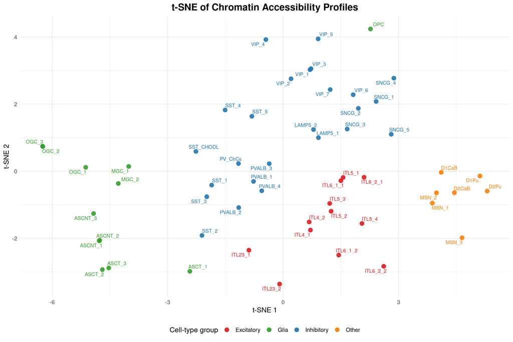

```r
cli::cli_h2("Creating t-SNE visualization")

# Create union of regions (limited for performance)
union_regions <- reduce(Reduce(c, accessibility_regions))
if (length(union_regions) > 5000) union_regions <- head(union_regions, 5000)

# Build score matrix
score_mat <- vapply(accessibility_regions, function(gr) {
  v <- numeric(length(union_regions))
  if (length(gr) > 0) {
    ov <- findOverlaps(union_regions, gr)
    v[queryHits(ov)] <- gr$score[subjectHits(ov)]
  }
  v
}, FUN.VALUE = numeric(length(union_regions)))

score_mat <- t(score_mat)
rownames(score_mat) <- all_cell_types

# Run t-SNE
perp <- min(30, floor((nrow(score_mat) - 1) / 3))
tsne_res <- Rtsne::Rtsne(score_mat, perplexity = perp, check_duplicates = FALSE, verbose = FALSE)

# Prepare data for plotting
tsne_df <- data.frame(
  tSNE1 = tsne_res$Y[, 1],
  tSNE2 = tsne_res$Y[, 2],
  CellType = rownames(score_mat)
)

cell_type_to_group <- unlist(lapply(names(cell_type_groups), function(g) {
  setNames(rep(g, length(cell_type_groups[[g]])), cell_type_groups[[g]])
}))
tsne_df$Group <- cell_type_to_group[tsne_df$CellType]

# Create plot
ggplot(tsne_df, aes(tSNE1, tSNE2, colour = Group)) +
  geom_point(size = 3, alpha = 0.9) +
  geom_text_repel(aes(label = CellType), size = 3, max.overlaps = 15) +
  scale_colour_manual(values = group_colors) +
  theme_minimal(base_size = 12) +
  theme(legend.position = "bottom",
        plot.title = element_text(size = 16, face = "bold", hjust = 0.5)) +
  labs(title = "t-SNE of Chromatin Accessibility Profiles",
       x = "t-SNE 1", y = "t-SNE 2", colour = "Cell-type group")
```

## Run GO Enrichment for All Backgrounds

```r
backgrounds <- params$backgrounds
cli::cli_h2("Running enrichment for backgrounds: {paste(backgrounds, collapse=', ')}")

enrichment_results_all <- setNames(vector("list", length(backgrounds)), backgrounds)
for (bg in backgrounds) {
  enrichment_results_all[[bg]] <- lapply(names(group_accessibility), function(grp) {
    perform_go_enrichment(group_accessibility[[grp]], grp, background = bg)
  })
  names(enrichment_results_all[[bg]]) <- names(group_accessibility)
}

# Use accessible background as main results for single-background plots
enrichment_results <- enrichment_results_all[["accessible"]]
successful_groups <- sum(sapply(enrichment_results, Negate(is.null)))
cli::cli_alert_success("Completed enrichment for {successful_groups}/{length(enrichment_results)} groups")
```

## Results by Background and Ontology

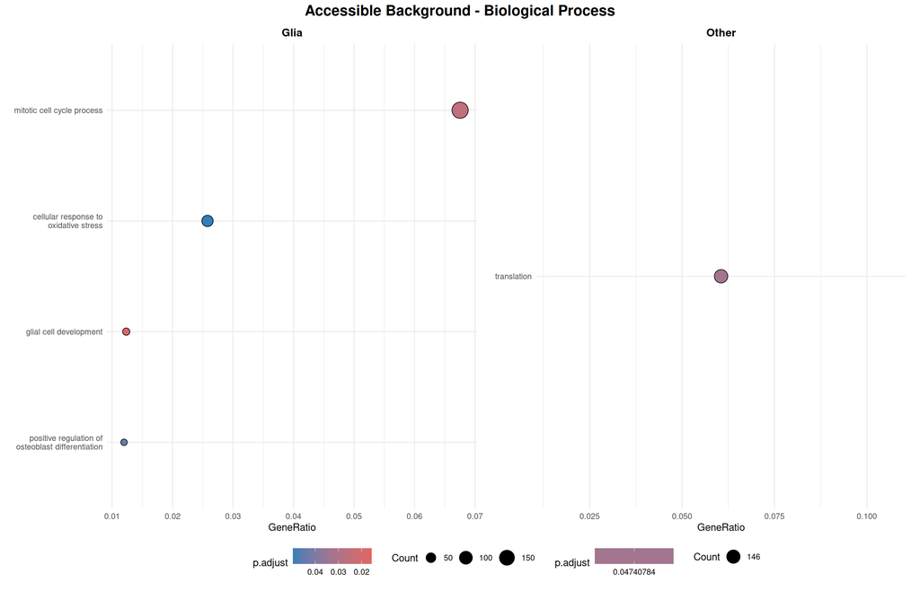

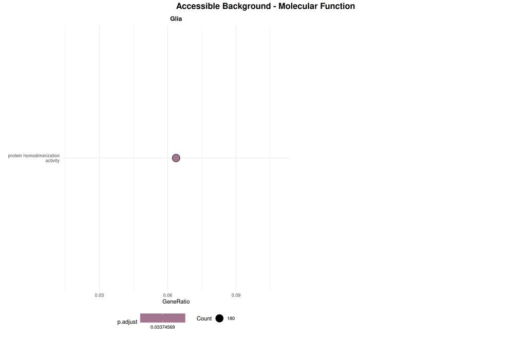

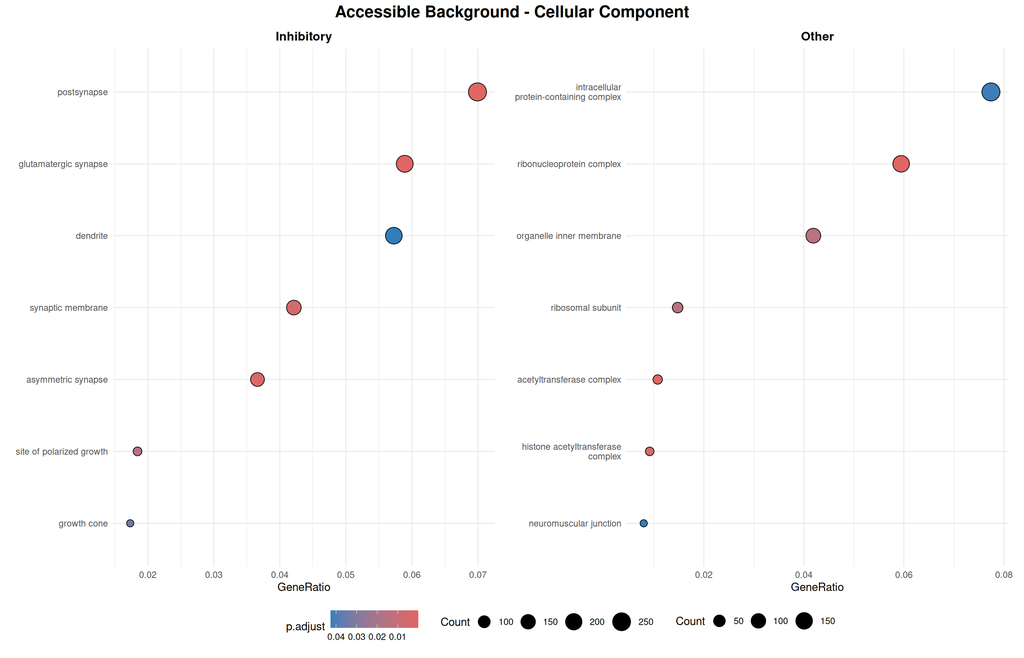

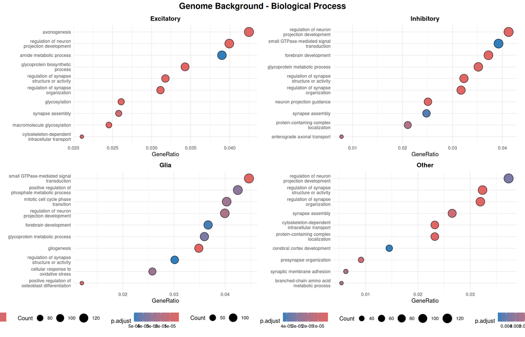

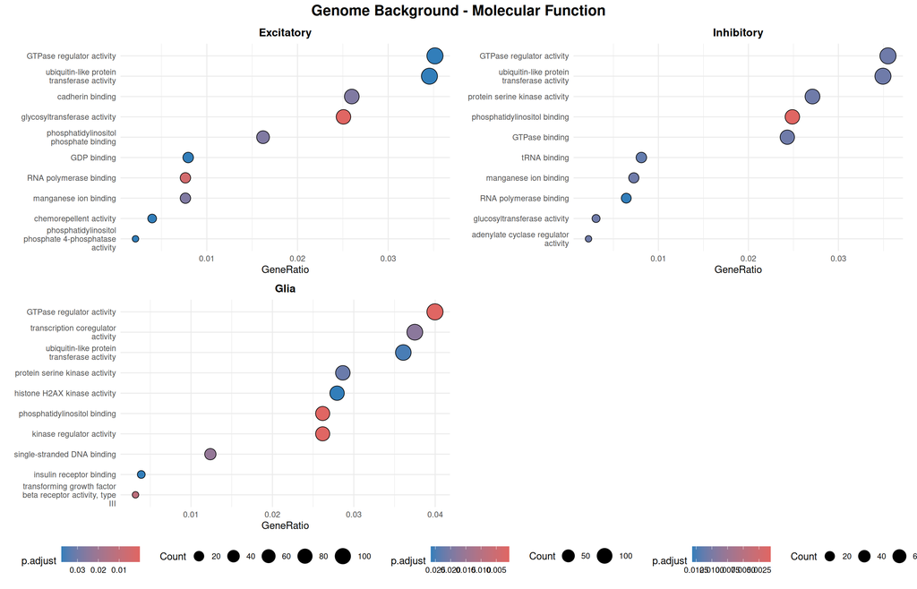

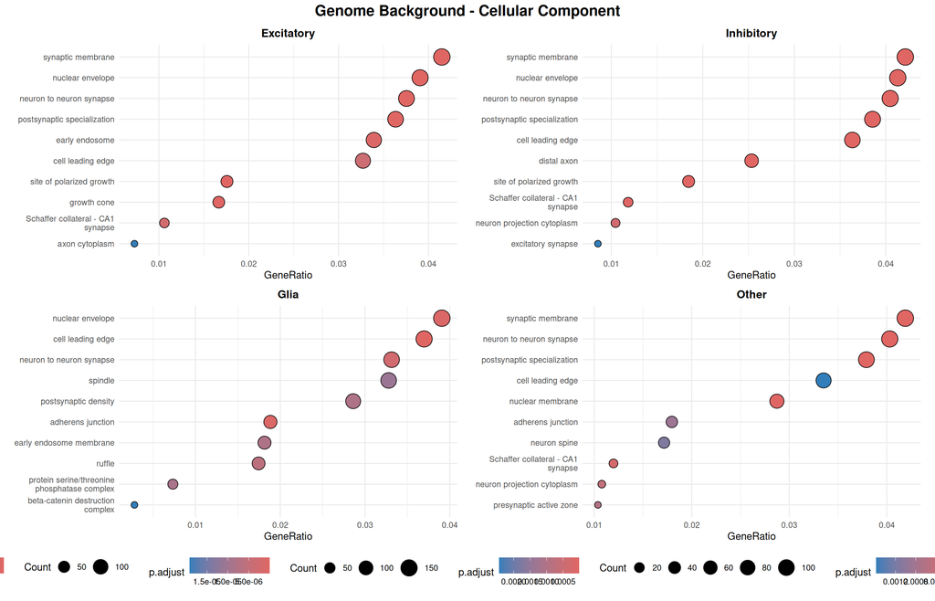

```r
# Create master list to store all plots
all_plots <- list()

for (bg in params$backgrounds) {
  bg_plots <- list()
  bg_name <- background_names[[bg]]

  # Generate plots for each ontology
  for (ont in c("BP", "MF", "CC")) {
    ont_plots <- generate_ontology_plots(enrichment_results_all[[bg]], ont, bg_name)

    # Skip if no plots generated
    if (length(ont_plots) == 0) next

    # Arrange in grid
    grid_plot <- wrap_plots(ont_plots, ncol = 2, guides = "collect") +
      plot_annotation(
        title = paste(bg_name, "-", expand_ontology_name(ont)),
        theme = theme(plot.title = element_text(size = 16, face = "bold", hjust = 0.5))
      ) & theme(legend.position = "bottom")

    # Store in master list
    bg_plots[[ont]] <- grid_plot
  }
  all_plots[[bg]] <- bg_plots
}

# Print all plots
for (bg in names(all_plots)) {
  bg_name <- background_names[[bg]]
  cli::cli_h2("{bg_name} Results")
  for (ont in names(all_plots[[bg]])) {
    print(all_plots[[bg]][[ont]])
    cat("\n\n")
  }
}
```

## Background Comparison Analysis

### Top GO Term Enrichment (-log10 adj-p)

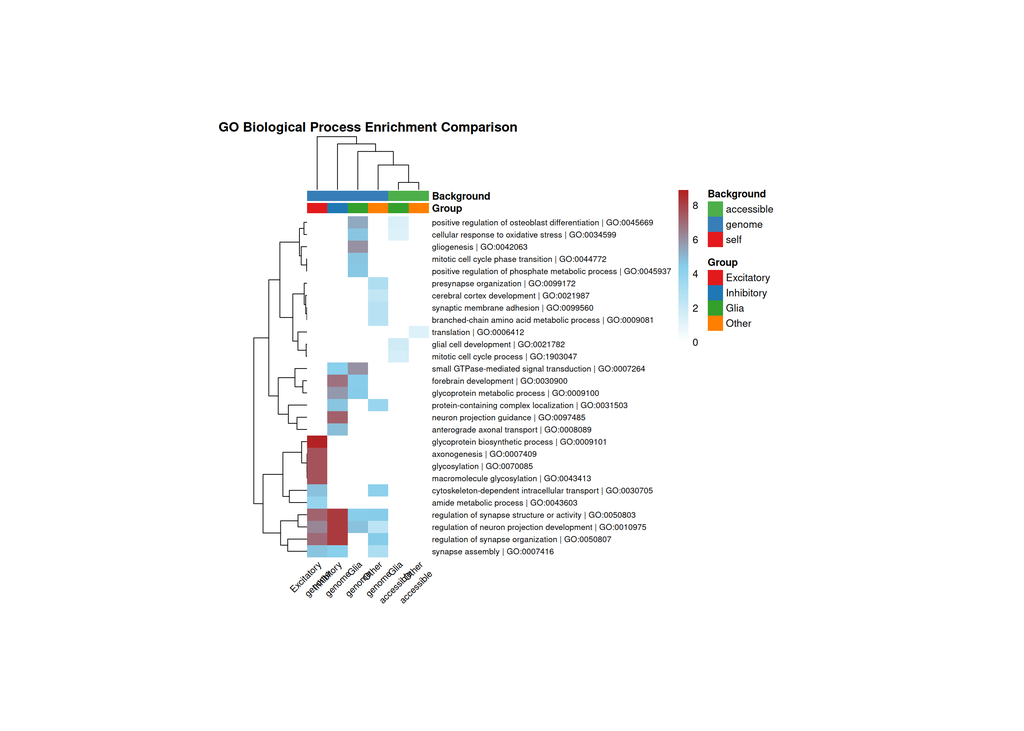

```r
ontology <- params$ontology
cli::cli_h2("Building heatmap for ontology: {expand_ontology_name(ontology)}")

# Aggregate results across all backgrounds
df_list <- lapply(names(enrichment_results_all), function(bg){
  df <- extract_enriched_terms(enrichment_results_all[[bg]], ontology = ontology)
  if (!is.null(df)) df$Background <- bg
  df
})
go_df_all <- do.call(rbind, df_list)

if (nrow(go_df_all) == 0) {
  cli::cli_alert_danger("No significant terms found - skipping heatmap")
} else {
  heatmap_df <- go_df_all %>%
    mutate(term = paste(Description, ID, sep = " | "),
           logp = -log10(p.adjust + 1e-10)) %>%
    select(Group, Background, term, logp) %>%
    unite(GroupBG, Group, Background, sep = "_") %>%
    pivot_wider(names_from = GroupBG, values_from = logp, values_fill = 0)
  mat <- as.matrix(heatmap_df[,-1])
  rownames(mat) <- heatmap_df$term

  # Create column annotations
  col_annot <- data.frame(
    Group = gsub("_.*", "", colnames(mat)),
    Background = gsub(".*_", "", colnames(mat))
  )
  rownames(col_annot) <- colnames(mat)

  ann_colors <- list(
    Group = group_colors,
    Background = c(accessible = "#4DAF4A", genome = "#377EB8", self = "#E41A1C")
  )

  pheatmap(mat,
           cluster_rows = TRUE,
           cluster_cols = TRUE,
           color = colorRampPalette(c("white", "skyblue", "firebrick"))(100),
           main = paste("GO", expand_ontology_name(ontology), "Enrichment Comparison"),
           fontsize_row = 8,
           fontsize_col = 9,
           annotation_col = col_annot,
           annotation_colors = ann_colors,
           labels_col = gsub("_", "\n", colnames(mat)),
           angle_col = 45,
           cellwidth = 20,
           cellheight = 12,
           border_color = NA)
}
```

### Shared Enriched Terms

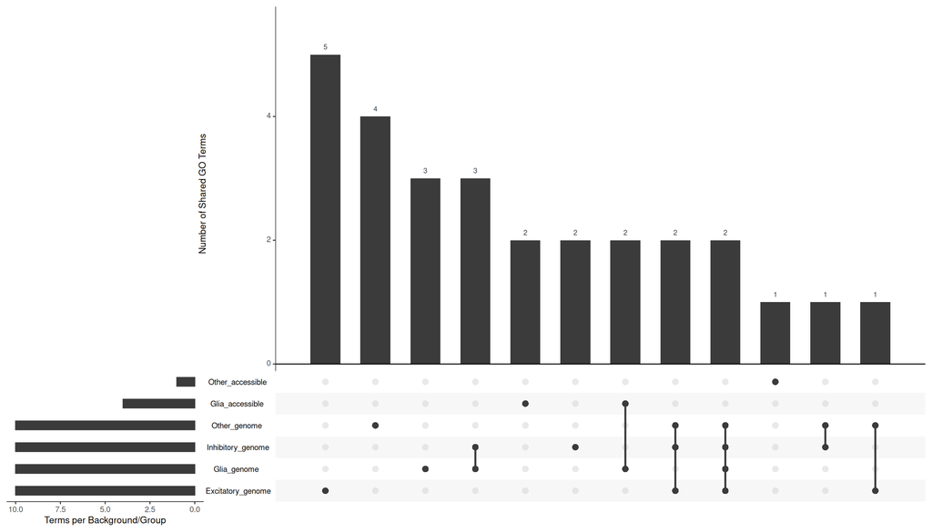

```r
cli::cli_h2("Term Overlap Between Backgrounds and Groups")
if (nrow(go_df_all) > 0) {
  term_lists <- go_df_all %>%
    mutate(key = paste(Group, Background, sep = "_")) %>%
    group_by(key) %>%
    summarise(terms = list(unique(paste(Description, ID, sep = " | "))), .groups = 'drop') %>%
    deframe()

  upset(fromList(term_lists),
        nsets = length(term_lists),
        order.by = "freq",
        sets = names(term_lists),
        mainbar.y.label = "Number of Shared GO Terms",
        sets.x.label = "Terms per Background/Group",
        text.scale = 1.2,
        point.size = 3,
        line.size = 1)
} else {
  cli::cli_alert_warning("No significant terms for UpSet plot")
}
```

## Parameters

```r
cat("\n### Analysis Parameters\n")
```

### Analysis Parameters

```r
cat("- **Backgrounds used:**", paste(params$backgrounds, collapse = ", "), "\n")
```

- **Backgrounds used:** accessible, genome, self

```r
cat("- **Primary ontology for comparison:**", expand_ontology_name(params$ontology), "\n")
```

- **Primary ontology for comparison:** Biological Process

```r
cat("- **Score threshold:**", params$threshold, "\n")
```

- **Score threshold:** 2

```r
cat("- **Max regions per cell type:**", format(params$top_n, big.mark = ","), "\n")
```

- **Max regions per cell type:** 5,000

```r
cat("- **Max regions per group:**", format(params$max_regions, big.mark = ","), "\n")
```

- **Max regions per group:** 10,000

```r
cat("- **Workers:**", params$workers, "\n")
```

- **Workers:** 4

```r
cat("- **System Info:**\n")
```

- **System Info:**

```r
sys_info <- Sys.info()
cat(paste0("  - ", names(sys_info), ": ", sys_info, collapse = "\n"), "\n")
```

- sysname: Linux
- release: 6.6.87.1-microsoft-standard-WSL2
- version: #1 SMP PREEMPT_DYNAMIC Mon Apr 21 17:08:54 UTC 2025
- nodename: PCNils
- machine: x86_64
- login: unknown
- user: nils
- effective_user: nils

```r
cat("\n- **Session Info:**\n")
```

- **Session Info:**

```r
cat(capture.output(sessionInfo()), sep = "\n")
```

R version 4.5.0 (2025-04-11) Platform: x86_64-pc-linux-gnu Running under: Ubuntu 24.04.2 LTS

Matrix products: default BLAS: /usr/lib/x86_64-linux-gnu/blas/libblas.so.3.12.0 LAPACK: /usr/lib/x86_64-linux-gnu/lapack/liblapack.so.3.12.0 LAPACK version 3.12.0

locale: [1] LC_CTYPE=C.UTF-8 LC_NUMERIC=C LC_TIME=C.UTF-8  
[4] LC_COLLATE=C.UTF-8 LC_MONETARY=C.UTF-8 LC_MESSAGES=C.UTF-8  
[7] LC_PAPER=C.UTF-8 LC_NAME=C LC_ADDRESS=C  
[10] LC_TELEPHONE=C LC_MEASUREMENT=C.UTF-8 LC_IDENTIFICATION=C

time zone: Europe/Zurich tzcode source: system (glibc)

attached base packages: [1] stats4 stats graphics grDevices utils datasets methods  
[8] base

other attached packages: [1] patchwork_1.3.0  
[2] cowplot_1.1.3  
[3] tibble_3.3.0  
[4] tidyr_1.3.1  
[5] UpSetR_1.4.0  
[6] pheatmap_1.0.13  
[7] ggrepel_0.9.6  
[8] Rtsne_0.17  
[9] cli_3.6.5  
[10] enrichplot_1.28.2  
[11] DT_0.33  
[12] ggplot2_3.5.2  
[13] dplyr_1.1.4  
[14] BiocParallel_1.42.1  
[15] TxDb.Hsapiens.UCSC.hg38.knownGene_3.21.0 [16] GenomicFeatures_1.60.0  
[17] org.Hs.eg.db_3.21.0  
[18] AnnotationDbi_1.70.0  
[19] Biobase_2.68.0  
[20] clusterProfiler_4.16.0  
[21] ChIPseeker_1.44.0  
[22] rGREAT_2.10.0  
[23] BiocFileCache_2.16.0  
[24] dbplyr_2.5.0  
[25] rtracklayer_1.68.0  
[26] GenomicRanges_1.60.0  
[27] GenomeInfoDb_1.44.0  
[28] IRanges_2.42.0  
[29] S4Vectors_0.46.0  
[30] BiocGenerics_0.54.0  
[31] generics_0.1.4